# C3하지혜_0525과제

```python
import pandas as pd
import matplotlib
import matplotlib.pyplot as plt
import seaborn as sns

# Scale 변환-> 설명변수 변환 : 회귀분석.설명변수 회귀계수 표준화
from sklearn.preprocessing import StandardScaler

import statsmodels.api as sm
from sklearn.decomposition import PCA

import numpy as np
```

```python
matplotlib.rc('font', family='NanumGothic')
matplotlib.rcParams['axes.unicode_minus'] = False
plt.rcParams["font.family"] = 'NanumGothic'
```

## 데이터 처리

```python
df_raw = pd.read_csv("../빅데이터 기초/Data/유방암.csv", encoding="euc-kr")
df_raw.head()
```

|  | diagnosis | mean_radius | mean_texture | mean_perimeter | mean_area | mean_smoothness | mean_compactness | mean_concavity | mean_concave_points | mean_symmetry | ... | worst_radius | worst_texture | worst_perimeter | worst_area | worst_smoothness | worst_compactness | worst_concavity | worst_concave_points | worst_symmetry | worst_fractal_dimension |
| --- | --- | --- | --- | --- | --- | --- | --- | --- | --- | --- | --- | --- | --- | --- | --- | --- | --- | --- | --- | --- | --- |
| 0 | 음성 | 15.12 | 16.68 | 98.78 | 716.6 | 0.08876 | 0.09588 | 0.07550 | 0.04079 | 0.1594 | ... | 17.77 | 20.24 | 117.70 | 989.5 | 0.14910 | 0.3331 | 0.3327 | 0.12520 | 0.3415 | 0.09740 |
| 1 | 양성 | 10.80 | 9.71 | 68.77 | 357.6 | 0.09594 | 0.05736 | 0.02531 | 0.01698 | 0.1381 | ... | 11.60 | 12.02 | 73.66 | 414.0 | 0.14360 | 0.1257 | 0.1047 | 0.04603 | 0.2090 | 0.07699 |
| 2 | 음성 | 18.31 | 18.58 | 118.60 | 1041.0 | 0.08588 | 0.08468 | 0.08169 | 0.05814 | 0.1621 | ... | 21.31 | 26.36 | 139.20 | 1410.0 | 0.12340 | 0.2445 | 0.3538 | 0.15710 | 0.3206 | 0.06938 |
| 3 | 양성 | 14.92 | 14.93 | 96.45 | 686.9 | 0.08098 | 0.08549 | 0.05539 | 0.03221 | 0.1687 | ... | 17.18 | 18.22 | 112.00 | 906.6 | 0.10650 | 0.2791 | 0.3151 | 0.11470 | 0.2688 | 0.08273 |
| 4 | 양성 | 12.89 | 13.12 | 81.89 | 515.9 | 0.06955 | 0.03729 | 0.02260 | 0.01171 | 0.1337 | ... | 13.62 | 15.54 | 87.40 | 577.0 | 0.09616 | 0.1147 | 0.1186 | 0.05366 | 0.2309 | 0.06915 |

5 rows × 31 columns

```python
# 데이터 분리 (Y, Xs) -> 설명변수를 이용한 주성분 분석
df_raw_x = df_raw.drop("diagnosis", axis = 1)
df_raw_y = df_raw["diagnosis"]
df_raw_y.head()
```

```
0    음성
1    양성
2    음성
3    양성
4    양성
Name: diagnosis, dtype: object
```

```python
df_raw_y.replace("양성", 1, inplace=True)
df_raw_y.replace("음성", 0, inplace=True)
```

양성을 1, 음성을 0으로 변환하였다.

```python
df_raw_y.head()
```

```
0    0
1    1
2    0
3    1
4    1
Name: diagnosis, dtype: int64
```

## 상관계수

```python
# Pearson 상관계수 : pearson, kendall, spearman
df_raw_x.corr().round(3)
```

|  | mean_radius | mean_texture | mean_perimeter | mean_area | mean_smoothness | mean_compactness | mean_concavity | mean_concave_points | mean_symmetry | mean_fractal_dimension | ... | worst_radius | worst_texture | worst_perimeter | worst_area | worst_smoothness | worst_compactness | worst_concavity | worst_concave_points | worst_symmetry | worst_fractal_dimension |
| --- | --- | --- | --- | --- | --- | --- | --- | --- | --- | --- | --- | --- | --- | --- | --- | --- | --- | --- | --- | --- | --- |
| mean_radius | 1.000 | 0.329 | 0.997 | 0.988 | 0.148 | 0.454 | 0.675 | 0.811 | 0.140 | -0.307 | ... | 0.959 | 0.272 | 0.955 | 0.931 | 0.071 | 0.297 | 0.470 | 0.697 | 0.076 | -0.059 |
| mean_texture | 0.329 | 1.000 | 0.336 | 0.317 | 0.002 | 0.253 | 0.309 | 0.297 | 0.050 | -0.051 | ... | 0.362 | 0.901 | 0.370 | 0.343 | 0.130 | 0.299 | 0.332 | 0.312 | 0.095 | 0.152 |
| mean_perimeter | 0.997 | 0.336 | 1.000 | 0.986 | 0.191 | 0.513 | 0.721 | 0.844 | 0.184 | -0.249 | ... | 0.958 | 0.279 | 0.960 | 0.930 | 0.106 | 0.346 | 0.513 | 0.728 | 0.105 | -0.011 |
| mean_area | 0.988 | 0.317 | 0.986 | 1.000 | 0.146 | 0.436 | 0.672 | 0.802 | 0.124 | -0.294 | ... | 0.949 | 0.250 | 0.946 | 0.946 | 0.061 | 0.268 | 0.444 | 0.665 | 0.042 | -0.076 |
| mean_smoothness | 0.148 | 0.002 | 0.191 | 0.146 | 1.000 | 0.678 | 0.592 | 0.578 | 0.584 | 0.643 | ... | 0.186 | 0.069 | 0.220 | 0.169 | 0.800 | 0.504 | 0.503 | 0.535 | 0.380 | 0.531 |
| mean_compactness | 0.454 | 0.253 | 0.513 | 0.436 | 0.678 | 1.000 | 0.890 | 0.812 | 0.670 | 0.625 | ... | 0.479 | 0.264 | 0.546 | 0.441 | 0.569 | 0.851 | 0.826 | 0.802 | 0.511 | 0.681 |
| mean_concavity | 0.675 | 0.309 | 0.721 | 0.672 | 0.592 | 0.890 | 1.000 | 0.935 | 0.544 | 0.360 | ... | 0.670 | 0.292 | 0.721 | 0.644 | 0.473 | 0.708 | 0.854 | 0.848 | 0.373 | 0.465 |
| mean_concave_points | 0.811 | 0.297 | 0.844 | 0.802 | 0.578 | 0.812 | 0.935 | 1.000 | 0.498 | 0.197 | ... | 0.806 | 0.283 | 0.839 | 0.774 | 0.436 | 0.597 | 0.731 | 0.891 | 0.329 | 0.321 |
| mean_symmetry | 0.140 | 0.050 | 0.184 | 0.124 | 0.584 | 0.670 | 0.544 | 0.498 | 1.000 | 0.540 | ... | 0.170 | 0.101 | 0.216 | 0.141 | 0.445 | 0.541 | 0.493 | 0.486 | 0.722 | 0.488 |
| mean_fractal_dimension | -0.307 | -0.051 | -0.249 | -0.294 | 0.643 | 0.625 | 0.360 | 0.197 | 0.540 | 1.000 | ... | -0.249 | 0.006 | -0.190 | -0.246 | 0.553 | 0.554 | 0.411 | 0.236 | 0.407 | 0.782 |
| radius_error | 0.705 | 0.250 | 0.716 | 0.749 | 0.264 | 0.442 | 0.608 | 0.675 | 0.233 | -0.051 | ... | 0.728 | 0.143 | 0.735 | 0.756 | 0.084 | 0.203 | 0.325 | 0.497 | 0.007 | -0.029 |
| texture_error | 0.015 | 0.353 | 0.029 | 0.029 | 0.111 | 0.128 | 0.148 | 0.111 | 0.158 | 0.149 | ... | -0.033 | 0.375 | -0.015 | -0.024 | -0.060 | -0.042 | -0.035 | -0.052 | -0.080 | -0.047 |
| perimeter_error | 0.687 | 0.253 | 0.706 | 0.731 | 0.263 | 0.499 | 0.640 | 0.686 | 0.258 | 0.008 | ... | 0.694 | 0.145 | 0.722 | 0.720 | 0.068 | 0.253 | 0.361 | 0.514 | 0.023 | 0.006 |
| area_error | 0.731 | 0.229 | 0.739 | 0.792 | 0.214 | 0.393 | 0.588 | 0.651 | 0.174 | -0.117 | ... | 0.743 | 0.137 | 0.748 | 0.795 | 0.061 | 0.184 | 0.317 | 0.479 | -0.020 | -0.059 |
| smoothness_error | -0.110 | 0.003 | -0.092 | -0.070 | 0.290 | 0.134 | 0.158 | 0.069 | 0.083 | 0.255 | ... | -0.162 | -0.106 | -0.147 | -0.132 | 0.223 | -0.056 | -0.034 | -0.071 | -0.177 | -0.012 |
| compactness_error | 0.210 | 0.230 | 0.260 | 0.206 | 0.377 | 0.750 | 0.648 | 0.487 | 0.458 | 0.551 | ... | 0.194 | 0.178 | 0.261 | 0.176 | 0.261 | 0.693 | 0.623 | 0.471 | 0.308 | 0.560 |
| concavity_error | 0.297 | 0.225 | 0.341 | 0.298 | 0.349 | 0.680 | 0.727 | 0.537 | 0.386 | 0.428 | ... | 0.257 | 0.147 | 0.316 | 0.242 | 0.217 | 0.544 | 0.665 | 0.484 | 0.198 | 0.402 |
| concave_points_error | 0.405 | 0.193 | 0.438 | 0.391 | 0.383 | 0.610 | 0.627 | 0.597 | 0.360 | 0.284 | ... | 0.366 | 0.093 | 0.413 | 0.337 | 0.197 | 0.389 | 0.465 | 0.569 | 0.103 | 0.220 |
| symmetry_error | -0.026 | -0.013 | -0.001 | -0.012 | 0.188 | 0.290 | 0.233 | 0.154 | 0.450 | 0.306 | ... | -0.080 | -0.076 | -0.047 | -0.084 | -0.031 | 0.122 | 0.085 | 0.038 | 0.453 | 0.076 |
| fractal_dimension_error | 0.019 | 0.104 | 0.064 | 0.023 | 0.376 | 0.594 | 0.474 | 0.316 | 0.381 | 0.671 | ... | 0.002 | 0.053 | 0.053 | -0.005 | 0.221 | 0.484 | 0.420 | 0.269 | 0.171 | 0.604 |
| worst_radius | 0.959 | 0.362 | 0.958 | 0.949 | 0.186 | 0.479 | 0.670 | 0.806 | 0.170 | -0.249 | ... | 1.000 | 0.352 | 0.992 | 0.983 | 0.181 | 0.371 | 0.522 | 0.749 | 0.163 | 0.039 |
| worst_texture | 0.272 | 0.901 | 0.279 | 0.250 | 0.069 | 0.264 | 0.292 | 0.283 | 0.101 | 0.006 | ... | 0.352 | 1.000 | 0.359 | 0.327 | 0.292 | 0.396 | 0.405 | 0.380 | 0.251 | 0.280 |
| worst_perimeter | 0.955 | 0.370 | 0.960 | 0.946 | 0.220 | 0.546 | 0.721 | 0.839 | 0.216 | -0.190 | ... | 0.992 | 0.359 | 1.000 | 0.974 | 0.206 | 0.433 | 0.576 | 0.784 | 0.193 | 0.088 |
| worst_area | 0.931 | 0.343 | 0.930 | 0.946 | 0.169 | 0.441 | 0.644 | 0.774 | 0.141 | -0.246 | ... | 0.983 | 0.327 | 0.974 | 1.000 | 0.161 | 0.326 | 0.479 | 0.698 | 0.114 | 0.010 |
| worst_smoothness | 0.071 | 0.130 | 0.106 | 0.061 | 0.800 | 0.569 | 0.473 | 0.436 | 0.445 | 0.553 | ... | 0.181 | 0.292 | 0.206 | 0.161 | 1.000 | 0.605 | 0.581 | 0.576 | 0.469 | 0.647 |
| worst_compactness | 0.297 | 0.299 | 0.346 | 0.268 | 0.504 | 0.851 | 0.708 | 0.597 | 0.541 | 0.554 | ... | 0.371 | 0.396 | 0.433 | 0.326 | 0.605 | 1.000 | 0.891 | 0.761 | 0.628 | 0.842 |
| worst_concavity | 0.470 | 0.332 | 0.513 | 0.444 | 0.503 | 0.826 | 0.854 | 0.731 | 0.493 | 0.411 | ... | 0.522 | 0.405 | 0.576 | 0.479 | 0.581 | 0.891 | 1.000 | 0.844 | 0.533 | 0.701 |
| worst_concave_points | 0.697 | 0.312 | 0.728 | 0.665 | 0.535 | 0.802 | 0.848 | 0.891 | 0.486 | 0.236 | ... | 0.749 | 0.380 | 0.784 | 0.698 | 0.576 | 0.761 | 0.844 | 1.000 | 0.488 | 0.506 |
| worst_symmetry | 0.076 | 0.095 | 0.105 | 0.042 | 0.380 | 0.511 | 0.373 | 0.329 | 0.722 | 0.407 | ... | 0.163 | 0.251 | 0.193 | 0.114 | 0.469 | 0.628 | 0.533 | 0.488 | 1.000 | 0.570 |
| worst_fractal_dimension | -0.059 | 0.152 | -0.011 | -0.076 | 0.531 | 0.681 | 0.465 | 0.321 | 0.488 | 0.782 | ... | 0.039 | 0.280 | 0.088 | 0.010 | 0.647 | 0.842 | 0.701 | 0.506 | 0.570 | 1.000 |

30 rows × 30 columns

-> mean_radius는 mean_perimeter, mean_area, worst_radius, worst_perimeter와 상관관계가 높다.  
-> mean_texture는 worst_texture와 상관관계가 높다.

## scale 변환

```python
# 요약 통계량 -> Scale 변환 필요 확인
df_raw_x.describe().round(3)
```

|  | mean_radius | mean_texture | mean_perimeter | mean_area | mean_smoothness | mean_compactness | mean_concavity | mean_concave_points | mean_symmetry | mean_fractal_dimension | ... | worst_radius | worst_texture | worst_perimeter | worst_area | worst_smoothness | worst_compactness | worst_concavity | worst_concave_points | worst_symmetry | worst_fractal_dimension |
| --- | --- | --- | --- | --- | --- | --- | --- | --- | --- | --- | --- | --- | --- | --- | --- | --- | --- | --- | --- | --- | --- |
| count | 320.000 | 320.000 | 320.000 | 320.000 | 320.000 | 320.000 | 320.000 | 320.000 | 320.000 | 320.000 | ... | 320.000 | 320.000 | 320.000 | 320.000 | 320.000 | 320.000 | 320.000 | 320.000 | 320.000 | 320.000 |
| mean | 15.710 | 20.323 | 103.050 | 807.736 | 0.099 | 0.123 | 0.122 | 0.067 | 0.187 | 0.063 | ... | 18.542 | 27.226 | 123.222 | 1133.463 | 0.138 | 0.309 | 0.353 | 0.145 | 0.305 | 0.087 |
| std | 3.746 | 4.151 | 25.836 | 391.969 | 0.014 | 0.057 | 0.085 | 0.042 | 0.027 | 0.007 | ... | 5.182 | 6.050 | 35.960 | 640.980 | 0.023 | 0.175 | 0.214 | 0.067 | 0.069 | 0.020 |
| min | 7.691 | 9.710 | 47.920 | 170.400 | 0.053 | 0.027 | 0.000 | 0.000 | 0.127 | 0.050 | ... | 8.678 | 12.020 | 54.490 | 223.600 | 0.086 | 0.050 | 0.000 | 0.000 | 0.156 | 0.055 |
| 25% | 13.050 | 17.460 | 84.845 | 523.900 | 0.090 | 0.081 | 0.053 | 0.030 | 0.167 | 0.057 | ... | 14.657 | 23.275 | 95.525 | 653.525 | 0.123 | 0.180 | 0.183 | 0.091 | 0.259 | 0.073 |
| 50% | 15.125 | 20.215 | 100.100 | 713.050 | 0.099 | 0.115 | 0.111 | 0.065 | 0.185 | 0.061 | ... | 17.730 | 26.880 | 118.850 | 969.200 | 0.138 | 0.277 | 0.340 | 0.153 | 0.296 | 0.083 |
| 75% | 18.520 | 22.500 | 121.550 | 1075.250 | 0.108 | 0.156 | 0.170 | 0.092 | 0.203 | 0.067 | ... | 22.420 | 30.938 | 148.850 | 1538.500 | 0.151 | 0.406 | 0.484 | 0.197 | 0.328 | 0.098 |
| max | 28.110 | 39.280 | 188.500 | 2501.000 | 0.163 | 0.345 | 0.427 | 0.201 | 0.304 | 0.097 | ... | 36.040 | 49.540 | 251.200 | 4254.000 | 0.223 | 1.058 | 1.170 | 0.291 | 0.664 | 0.208 |

8 rows × 30 columns

```python
# 변수 이름 저장
x_cols = df_raw_x.columns
# Scale 변환: ndarray 형식
scaler = StandardScaler()
nd_scaled = scaler.fit_transform(df_raw_x)
# 변환된 데이터 및 형태 확인
print("Scaled Data : \n {}".format(nd_scaled[:5].round(3)))
print("Shape:\n {}".format(nd_scaled.shape))
```

```
Scaled Data :
 [[-0.158 -0.879 -0.166 -0.233 -0.745 -0.479 -0.551 -0.628 -0.997 -0.393
  -0.693 -1.741 -0.65  -0.516 -0.499 -0.513 -0.671 -0.865 -0.592 -0.457
  -0.149 -1.156 -0.154 -0.225  0.491  0.139 -0.094 -0.302  0.526  0.511]
 [-1.313 -2.561 -1.329 -1.15  -0.24  -1.154 -1.143 -1.2   -1.774  0.184
  -0.995 -1.649 -1.003 -0.784  0.325 -1.023 -1.067 -1.361 -0.892 -0.801
  -1.342 -2.517 -1.38  -1.124  0.254 -1.046 -1.159 -1.48  -1.388 -0.507]
 [ 0.695 -0.421  0.603  0.596 -0.947 -0.675 -0.478 -0.212 -0.899 -1.174
  -0.734 -1.505 -0.715 -0.471 -1.419 -1.058 -0.936 -1.127 -1.099 -1.269
   0.535 -0.143  0.445  0.432 -0.613 -0.367  0.004  0.173  0.224 -0.887]
 [-0.211 -1.301 -0.256 -0.309 -1.292 -0.661 -0.788 -0.834 -0.659 -0.834
  -0.774 -1.593 -0.712 -0.572 -1.276 -0.594 -0.557 -0.841 -1.011 -0.684
  -0.263 -1.491 -0.313 -0.354 -1.339 -0.169 -0.177 -0.458 -0.524 -0.221]
 [-0.754 -1.738 -0.82  -0.746 -2.095 -1.505 -1.175 -1.326 -1.934 -0.957
  -1.055 -1.518 -1.008 -0.763 -0.761 -0.826 -0.834 -1.266 -0.484 -0.819
  -0.951 -1.935 -0.998 -0.87  -1.784 -1.109 -1.094 -1.367 -1.071 -0.898]]
Shape:
 (320, 30)
```

```python
# DataFrame으로 저장
df_scaled = pd.DataFrame(nd_scaled, columns=x_cols)
df_scaled.head().round(3)
```

|  | mean_radius | mean_texture | mean_perimeter | mean_area | mean_smoothness | mean_compactness | mean_concavity | mean_concave_points | mean_symmetry | mean_fractal_dimension | ... | worst_radius | worst_texture | worst_perimeter | worst_area | worst_smoothness | worst_compactness | worst_concavity | worst_concave_points | worst_symmetry | worst_fractal_dimension |
| --- | --- | --- | --- | --- | --- | --- | --- | --- | --- | --- | --- | --- | --- | --- | --- | --- | --- | --- | --- | --- | --- |
| 0 | -0.158 | -0.879 | -0.166 | -0.233 | -0.745 | -0.479 | -0.551 | -0.628 | -0.997 | -0.393 | ... | -0.149 | -1.156 | -0.154 | -0.225 | 0.491 | 0.139 | -0.094 | -0.302 | 0.526 | 0.511 |
| 1 | -1.313 | -2.561 | -1.329 | -1.150 | -0.240 | -1.154 | -1.143 | -1.200 | -1.774 | 0.184 | ... | -1.342 | -2.517 | -1.380 | -1.124 | 0.254 | -1.046 | -1.159 | -1.480 | -1.388 | -0.507 |
| 2 | 0.695 | -0.421 | 0.603 | 0.596 | -0.947 | -0.675 | -0.478 | -0.212 | -0.899 | -1.174 | ... | 0.535 | -0.143 | 0.445 | 0.432 | -0.613 | -0.367 | 0.004 | 0.173 | 0.224 | -0.887 |
| 3 | -0.211 | -1.301 | -0.256 | -0.309 | -1.292 | -0.661 | -0.788 | -0.834 | -0.659 | -0.834 | ... | -0.263 | -1.491 | -0.313 | -0.354 | -1.339 | -0.169 | -0.177 | -0.458 | -0.524 | -0.221 |
| 4 | -0.754 | -1.738 | -0.820 | -0.746 | -2.095 | -1.505 | -1.175 | -1.326 | -1.934 | -0.957 | ... | -0.951 | -1.935 | -0.998 | -0.870 | -1.784 | -1.109 | -1.094 | -1.367 | -1.071 | -0.898 |

5 rows × 30 columns

```python
# Scale 변환 데이터 요약 통계량
df_scaled.describe().round(3)
```

|  | mean_radius | mean_texture | mean_perimeter | mean_area | mean_smoothness | mean_compactness | mean_concavity | mean_concave_points | mean_symmetry | mean_fractal_dimension | ... | worst_radius | worst_texture | worst_perimeter | worst_area | worst_smoothness | worst_compactness | worst_concavity | worst_concave_points | worst_symmetry | worst_fractal_dimension |
| --- | --- | --- | --- | --- | --- | --- | --- | --- | --- | --- | --- | --- | --- | --- | --- | --- | --- | --- | --- | --- | --- |
| count | 320.000 | 320.000 | 320.000 | 320.000 | 320.000 | 320.000 | 320.000 | 320.000 | 320.000 | 320.000 | ... | 320.000 | 320.000 | 320.000 | 320.000 | 320.000 | 320.000 | 320.000 | 320.000 | 320.000 | 320.000 |
| mean | 0.000 | -0.000 | -0.000 | 0.000 | 0.000 | -0.000 | 0.000 | -0.000 | 0.000 | 0.000 | ... | 0.000 | 0.000 | 0.000 | -0.000 | -0.000 | 0.000 | -0.000 | -0.000 | 0.000 | 0.000 |
| std | 1.002 | 1.002 | 1.002 | 1.002 | 1.002 | 1.002 | 1.002 | 1.002 | 1.002 | 1.002 | ... | 1.002 | 1.002 | 1.002 | 1.002 | 1.002 | 1.002 | 1.002 | 1.002 | 1.002 | 1.002 |
| min | -2.144 | -2.561 | -2.137 | -1.629 | -3.284 | -1.690 | -1.442 | -1.607 | -2.164 | -1.772 | ... | -1.906 | -2.517 | -1.914 | -1.422 | -2.234 | -1.477 | -1.648 | -2.165 | -2.146 | -1.602 |
| 25% | -0.711 | -0.691 | -0.706 | -0.725 | -0.641 | -0.737 | -0.819 | -0.899 | -0.724 | -0.728 | ... | -0.751 | -0.654 | -0.771 | -0.750 | -0.645 | -0.734 | -0.794 | -0.813 | -0.670 | -0.683 |
| 50% | -0.156 | -0.026 | -0.114 | -0.242 | -0.055 | -0.139 | -0.133 | -0.041 | -0.077 | -0.172 | ... | -0.157 | -0.057 | -0.122 | -0.257 | 0.016 | -0.182 | -0.062 | 0.107 | -0.134 | -0.225 |
| 75% | 0.751 | 0.525 | 0.717 | 0.684 | 0.611 | 0.567 | 0.560 | 0.595 | 0.580 | 0.561 | ... | 0.749 | 0.614 | 0.714 | 0.633 | 0.581 | 0.554 | 0.611 | 0.768 | 0.332 | 0.528 |
| max | 3.316 | 4.574 | 3.313 | 4.327 | 4.501 | 3.889 | 3.597 | 3.221 | 4.272 | 4.842 | ... | 3.382 | 3.694 | 3.564 | 4.876 | 3.648 | 4.283 | 3.816 | 2.166 | 5.179 | 6.004 |

8 rows × 30 columns

-> 평균이 0, 표준편차가 약 1인 정규분포로 변환된 것을 확인할 수 있다.

## 주성분 분석

```python
# 주성분 분석: 주성분1(Prin1)~주성분6(Prin6) 생성 및 저장
pca = PCA(n_components=30)
nd_pca = pca.fit_transform(df_scaled)

# 생성된 주성분 점수 확인
print("PCA Data : \n {}".format(nd_pca[:30]))

# 생성된 주성분 점수 Row, Col 개수 확인
print("Shape :\n {}".format(nd_pca.shape))
```

[output not shown]

[output cut: 188 more lines]

[output not shown]

```python
# 주성분 점수 저장(Prin1~Prin6, DataFrame 형식) 및 확인
df_pca = pd.DataFrame(nd_pca,
                      columns= ["Prin1","Prin2","Prin3","Prin4","Prin5",
                                "Prin6","Prin7","Prin8","Prin9","Prin10",
                                "Prin11","Prin12","Prin13","Prin14","Prin15",
                                "Prin16","Prin17","Prin18","Prin19","Prin20",
                                "Prin21","Prin22","Prin23","Prin24","Prin25",
                                "Prin26","Prin27","Prin28","Prin29","Prin30"])
# 주성분 분석용 데이터와 주성분 점수 결합
df_scaled_pca = df_scaled.join(df_pca)
df_scaled_pca.head()
```

|  | mean_radius | mean_texture | mean_perimeter | mean_area | mean_smoothness | mean_compactness | mean_concavity | mean_concave_points | mean_symmetry | mean_fractal_dimension | ... | Prin21 | Prin22 | Prin23 | Prin24 | Prin25 | Prin26 | Prin27 | Prin28 | Prin29 | Prin30 |
| --- | --- | --- | --- | --- | --- | --- | --- | --- | --- | --- | --- | --- | --- | --- | --- | --- | --- | --- | --- | --- | --- |
| 0 | -0.157678 | -0.879112 | -0.165550 | -0.232872 | -0.744948 | -0.479220 | -0.550769 | -0.628488 | -0.997431 | -0.392627 | ... | 0.244217 | 0.164854 | 0.066377 | 0.180670 | -0.001146 | 0.008636 | -0.068607 | 0.000605 | 0.025802 | 0.014159 |
| 1 | -1.312779 | -2.560965 | -1.328928 | -1.150194 | -0.240274 | -1.153621 | -1.143404 | -1.199934 | -1.773612 | 0.184077 | ... | 0.108090 | 0.168014 | -0.064889 | -0.043477 | 0.014914 | -0.043391 | -0.049777 | 0.012085 | 0.014942 | 0.003802 |
| 2 | 0.695279 | -0.420644 | 0.602798 | 0.596040 | -0.947380 | -0.675307 | -0.477679 | -0.212084 | -0.899042 | -1.174101 | ... | -0.034971 | -0.296615 | -0.089094 | -0.111252 | -0.078950 | -0.050892 | 0.067030 | 0.030987 | 0.012601 | -0.003082 |
| 3 | -0.211154 | -1.301385 | -0.255876 | -0.308762 | -1.291796 | -0.661126 | -0.788224 | -0.834410 | -0.658535 | -0.834209 | ... | -0.009942 | -0.103717 | 0.066354 | 0.105339 | -0.013316 | -0.011097 | -0.021080 | 0.033756 | -0.021498 | 0.005064 |
| 4 | -0.753945 | -1.738136 | -0.820314 | -0.745704 | -2.095198 | -1.505004 | -1.175403 | -1.326415 | -1.933950 | -0.956793 | ... | 0.072100 | 0.129423 | -0.003367 | 0.020147 | -0.045760 | 0.052844 | -0.065091 | 0.017130 | 0.021292 | -0.001706 |

5 rows × 60 columns

```python
# 주성분 분석 통계량 저장: 주성분 번호, Eigenvalue, Eigenvalue ratio
df_pca_stat = pd.DataFrame()
df_pca_stat["PrinNo"] = [l for l in range(1, 31)]
df_pca_stat["EigenValues"] = pca.explained_variance_
df_pca_stat["EigenValueRatio"] = pca.explained_variance_ratio_
df_pca_stat["CumEigenValueRatio"] = np.cumsum(pca.explained_variance_ratio_)
df_pca_stat.round(3)
```

|  | PrinNo | EigenValues | EigenValueRatio | CumEigenValueRatio |
| --- | --- | --- | --- | --- |
| 0 | 1 | 13.125 | 0.436 | 0.436 |
| 1 | 2 | 5.982 | 0.199 | 0.635 |
| 2 | 3 | 3.116 | 0.104 | 0.738 |
| 3 | 4 | 1.950 | 0.065 | 0.803 |
| 4 | 5 | 1.319 | 0.044 | 0.847 |
| 5 | 6 | 1.252 | 0.042 | 0.889 |
| 6 | 7 | 0.749 | 0.025 | 0.914 |
| 7 | 8 | 0.534 | 0.018 | 0.931 |
| 8 | 9 | 0.376 | 0.012 | 0.944 |
| 9 | 10 | 0.321 | 0.011 | 0.954 |
| 10 | 11 | 0.290 | 0.010 | 0.964 |
| 11 | 12 | 0.266 | 0.009 | 0.973 |
| 12 | 13 | 0.173 | 0.006 | 0.979 |
| 13 | 14 | 0.148 | 0.005 | 0.984 |
| 14 | 15 | 0.107 | 0.004 | 0.987 |
| 15 | 16 | 0.070 | 0.002 | 0.989 |
| 16 | 17 | 0.064 | 0.002 | 0.992 |
| 17 | 18 | 0.054 | 0.002 | 0.993 |
| 18 | 19 | 0.048 | 0.002 | 0.995 |
| 19 | 20 | 0.033 | 0.001 | 0.996 |
| 20 | 21 | 0.031 | 0.001 | 0.997 |
| 21 | 22 | 0.023 | 0.001 | 0.998 |
| 22 | 23 | 0.021 | 0.001 | 0.999 |
| 23 | 24 | 0.014 | 0.000 | 0.999 |
| 24 | 25 | 0.011 | 0.000 | 0.999 |
| 25 | 26 | 0.009 | 0.000 | 1.000 |
| 26 | 27 | 0.006 | 0.000 | 1.000 |
| 27 | 28 | 0.002 | 0.000 | 1.000 |
| 28 | 29 | 0.001 | 0.000 | 1.000 |
| 29 | 30 | 0.000 | 0.000 | 1.000 |

적정 주성분을 선택하는 기준은 다음과 같다.

- 상관계수 기준(고유값 >1): 6개
- 공분산 기준(고유값 누적비율>0.8): 4개

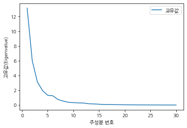

```python
# Scree Plot
plt.plot(df_pca_stat["PrinNo"], df_pca_stat["EigenValues"], label="교유값")

# 그래프 label, legend 설정
plt.ylabel("고유값(Eigenvalue)")
plt.xlabel("주성분 번호")
plt.legend(loc="best")
```

고유값 기준으로는, 고유값이 급격히 변화하는 지점(5~7)에서 주성분 개수를 결정하는 것이 좋다.

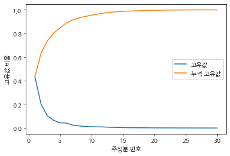

```python
# 고유값 비율 그래프 생성
plt.plot(df_pca_stat["PrinNo"], df_pca_stat["EigenValueRatio"], label="고유값")

# 누적된 고유값 비율 그래프 생성
plt.plot(df_pca_stat["PrinNo"], df_pca_stat["CumEigenValueRatio"], label="누적 고유값")
plt.ylabel("고유값 비율")
plt.xlabel("주성분 번호")
plt.legend(loc="best")
```

고유값 비율을 보면, 4~5에서 주성분 개수를 결정하는 것이 좋다.

```python
# 주성분 분석 데이터의 변수 이름
x_cols = pd.DataFrame({"Feature": df_raw_x.columns})

# 주성분 Prin1~30까지의 고유벡터 저장
# 파이썬 PCA 분석 시 SVD 연산 방식의 차이 반영(전치, 부호 변경)
df_eigenvector = pd.concat([x_cols, pd.DataFrame(pca.components_.T * -1, \
                            columns= ["Prin1","Prin2","Prin3","Prin4","Prin5",
                                "Prin6","Prin7","Prin8","Prin9","Prin10",
                                "Prin11","Prin12","Prin13","Prin14","Prin15",
                                "Prin16","Prin17","Prin18","Prin19","Prin20",
                                "Prin21","Prin22","Prin23","Prin24","Prin25",
                                "Prin26","Prin27","Prin28","Prin29","Prin30"])], axis=1)
df_eigenvector.round(3)
```

|  | Feature | Prin1 | Prin2 | Prin3 | Prin4 | Prin5 | Prin6 | Prin7 | Prin8 | Prin9 | ... | Prin21 | Prin22 | Prin23 | Prin24 | Prin25 | Prin26 | Prin27 | Prin28 | Prin29 | Prin30 |
| --- | --- | --- | --- | --- | --- | --- | --- | --- | --- | --- | --- | --- | --- | --- | --- | --- | --- | --- | --- | --- | --- |
| 0 | mean_radius | -0.214 | 0.238 | 0.026 | 0.026 | -0.007 | -0.068 | 0.156 | -0.097 | -0.196 | ... | 0.166 | 0.074 | -0.078 | 0.131 | 0.070 | -0.082 | 0.168 | -0.180 | -0.218 | 0.706 |
| 1 | mean_texture | -0.110 | 0.046 | 0.038 | -0.604 | 0.042 | 0.101 | -0.030 | 0.138 | 0.097 | ... | -0.251 | 0.109 | -0.136 | -0.183 | -0.070 | -0.017 | 0.040 | -0.002 | 0.006 | 0.002 |
| 2 | mean_perimeter | -0.225 | 0.218 | 0.024 | 0.029 | -0.010 | -0.068 | 0.147 | -0.106 | -0.182 | ... | 0.113 | 0.072 | -0.027 | 0.048 | 0.095 | -0.072 | 0.168 | -0.087 | -0.376 | -0.689 |
| 3 | mean_area | -0.213 | 0.245 | -0.002 | 0.040 | -0.010 | -0.035 | 0.082 | -0.048 | -0.229 | ... | -0.032 | -0.035 | 0.137 | 0.060 | -0.114 | 0.142 | -0.543 | 0.259 | 0.438 | -0.042 |
| 4 | mean_smoothness | -0.151 | -0.194 | 0.058 | 0.201 | -0.037 | 0.474 | 0.074 | -0.196 | -0.012 | ... | 0.076 | 0.107 | 0.058 | -0.064 | 0.008 | -0.057 | -0.069 | -0.009 | 0.003 | -0.007 |
| 5 | mean_compactness | -0.240 | -0.163 | 0.046 | 0.053 | -0.024 | -0.040 | -0.025 | -0.136 | 0.011 | ... | -0.184 | 0.053 | -0.350 | -0.201 | 0.202 | 0.266 | -0.169 | 0.008 | 0.050 | 0.051 |
| 6 | mean_concavity | -0.261 | -0.046 | 0.003 | 0.046 | -0.060 | -0.019 | 0.107 | -0.057 | 0.024 | ... | -0.259 | -0.314 | 0.112 | 0.046 | 0.039 | -0.637 | -0.129 | -0.056 | 0.011 | 0.021 |
| 7 | mean_concave_points | -0.260 | 0.039 | 0.035 | 0.086 | -0.008 | 0.067 | 0.154 | -0.191 | -0.009 | ... | 0.092 | -0.325 | 0.099 | 0.065 | -0.168 | 0.527 | 0.291 | 0.029 | 0.004 | 0.003 |
| 8 | mean_symmetry | -0.147 | -0.197 | 0.047 | 0.138 | 0.428 | 0.061 | 0.054 | -0.219 | 0.176 | ... | 0.100 | -0.003 | 0.064 | 0.021 | -0.024 | -0.026 | 0.008 | -0.007 | 0.009 | -0.001 |
| 9 | mean_fractal_dimension | -0.076 | -0.351 | -0.000 | 0.080 | -0.056 | 0.104 | -0.290 | -0.176 | -0.104 | ... | 0.116 | 0.181 | 0.092 | 0.247 | -0.011 | -0.079 | 0.125 | 0.008 | -0.008 | -0.003 |
| 10 | radius_error | -0.202 | 0.158 | -0.205 | 0.088 | 0.080 | 0.152 | -0.362 | 0.143 | 0.162 | ... | 0.233 | -0.062 | -0.433 | 0.426 | 0.005 | -0.028 | -0.235 | 0.232 | -0.118 | -0.023 |
| 11 | texture_error | -0.050 | -0.062 | -0.346 | -0.359 | 0.182 | 0.208 | 0.037 | -0.493 | -0.107 | ... | -0.112 | 0.059 | -0.136 | -0.116 | -0.044 | -0.004 | 0.020 | 0.008 | 0.008 | 0.000 |
| 12 | perimeter_error | -0.208 | 0.132 | -0.226 | 0.075 | 0.079 | 0.091 | -0.359 | 0.091 | 0.239 | ... | 0.152 | 0.111 | 0.531 | -0.321 | -0.063 | 0.067 | -0.131 | -0.321 | -0.011 | 0.023 |
| 13 | area_error | -0.195 | 0.187 | -0.168 | 0.100 | 0.054 | 0.133 | -0.386 | 0.195 | 0.061 | ... | -0.311 | 0.033 | -0.125 | -0.075 | 0.094 | -0.005 | 0.409 | 0.058 | 0.100 | 0.007 |
| 14 | smoothness_error | -0.033 | -0.125 | -0.373 | 0.014 | -0.189 | 0.341 | 0.325 | 0.453 | -0.252 | ... | 0.068 | 0.091 | 0.060 | -0.012 | 0.052 | 0.003 | -0.001 | -0.018 | -0.002 | 0.000 |
| 15 | compactness_error | -0.179 | -0.209 | -0.194 | -0.083 | -0.104 | -0.281 | -0.018 | 0.071 | -0.090 | ... | 0.119 | -0.132 | 0.082 | 0.015 | 0.404 | -0.063 | -0.016 | 0.016 | 0.006 | -0.001 |
| 16 | concavity_error | -0.185 | -0.154 | -0.238 | -0.054 | -0.166 | -0.252 | 0.159 | 0.163 | 0.141 | ... | 0.271 | -0.050 | -0.231 | -0.240 | -0.374 | 0.090 | 0.031 | -0.005 | -0.020 | -0.005 |
| 17 | concave_points_error | -0.186 | -0.074 | -0.272 | 0.006 | -0.119 | -0.077 | 0.253 | -0.106 | 0.534 | ... | -0.214 | -0.226 | 0.079 | 0.164 | 0.074 | -0.012 | 0.048 | 0.036 | 0.029 | -0.002 |
| 18 | symmetry_error | -0.064 | -0.147 | -0.285 | 0.057 | 0.550 | -0.119 | 0.127 | 0.236 | -0.205 | ... | 0.051 | -0.028 | 0.011 | 0.016 | -0.017 | -0.019 | 0.033 | 0.008 | 0.007 | -0.000 |
| 19 | fractal_dimension_error | -0.127 | -0.246 | -0.237 | -0.049 | -0.181 | -0.192 | -0.179 | -0.166 | -0.363 | ... | -0.202 | 0.253 | 0.083 | 0.125 | -0.122 | 0.040 | -0.044 | -0.011 | -0.003 | 0.000 |
| 20 | worst_radius | -0.221 | 0.225 | 0.090 | 0.008 | 0.003 | -0.013 | 0.027 | -0.005 | -0.144 | ... | 0.094 | -0.000 | -0.172 | 0.067 | 0.044 | -0.107 | 0.224 | -0.429 | 0.617 | -0.120 |
| 21 | worst_texture | -0.106 | 0.011 | 0.148 | -0.609 | 0.087 | 0.156 | -0.028 | 0.051 | 0.027 | ... | 0.336 | -0.126 | 0.217 | 0.259 | 0.102 | 0.020 | -0.058 | 0.001 | -0.012 | -0.001 |
| 22 | worst_perimeter | -0.233 | 0.202 | 0.083 | 0.008 | -0.000 | -0.034 | 0.020 | -0.012 | -0.097 | ... | 0.044 | 0.100 | 0.224 | -0.242 | -0.020 | -0.159 | 0.266 | 0.700 | -0.009 | 0.068 |
| 23 | worst_area | -0.215 | 0.234 | 0.064 | 0.020 | -0.005 | 0.019 | -0.054 | 0.038 | -0.179 | ... | -0.287 | -0.148 | 0.023 | -0.055 | -0.067 | 0.138 | -0.291 | -0.221 | -0.455 | 0.040 |
| 24 | worst_smoothness | -0.128 | -0.193 | 0.229 | 0.054 | -0.123 | 0.481 | 0.105 | 0.214 | -0.043 | ... | -0.142 | -0.122 | -0.045 | 0.021 | -0.062 | 0.040 | 0.043 | 0.010 | -0.009 | 0.004 |
| 25 | worst_compactness | -0.199 | -0.190 | 0.209 | -0.066 | -0.063 | -0.172 | -0.108 | 0.132 | 0.014 | ... | -0.104 | 0.059 | 0.065 | 0.246 | -0.605 | -0.095 | 0.089 | -0.045 | -0.011 | -0.015 |
| 26 | worst_concavity | -0.225 | -0.120 | 0.180 | -0.050 | -0.118 | -0.153 | 0.059 | 0.146 | 0.152 | ... | -0.145 | 0.335 | 0.166 | 0.224 | 0.380 | 0.281 | 0.018 | 0.016 | 0.019 | 0.002 |
| 27 | worst_concave_points | -0.247 | -0.010 | 0.180 | 0.034 | -0.050 | -0.010 | 0.164 | -0.025 | 0.223 | ... | 0.239 | 0.446 | -0.206 | -0.233 | -0.016 | -0.192 | -0.174 | -0.032 | -0.040 | -0.004 |
| 28 | worst_symmetry | -0.111 | -0.184 | 0.239 | 0.041 | 0.524 | -0.099 | 0.084 | 0.226 | -0.056 | ... | -0.165 | 0.023 | -0.027 | -0.029 | 0.039 | 0.039 | -0.038 | -0.001 | -0.018 | -0.000 |
| 29 | worst_fractal_dimension | -0.124 | -0.289 | 0.208 | -0.046 | -0.126 | -0.068 | -0.315 | 0.027 | -0.182 | ... | 0.217 | -0.426 | -0.102 | -0.357 | 0.152 | -0.021 | -0.008 | 0.017 | -0.005 | 0.004 |

30 rows × 31 columns

1주성분은 mean_concavity, worst_concave_points 등의 변수와 음의 연관성을 가진다. 또한, 전체적으로 모든 변수와 음의 연관성을 가지고 있다.  
2주성분은 mean_fractal_dimension, worst_fractal_dimension 등의 변수와 음의 연관성을 가진다.  
3주성분은 smoothness_error, texture_error 등의 변수와 음의 연관성을 가진다.  
4주성분은 mean_texture, worst_texture와 강한 음의 연관성을 가진다.  
5주성분은 symmetry_error, worst_symmetry와 강한 양의 연관성을 가진다.  
6주성분은 mean_smoothness, smoothness_error 등의 변수와 양의 연관성을 가진다. 7주성분은 perimeter_error, area_error와 음의 연관성을 가진다.

```python
#상관계수
df_pca.corr().round(3)
```

|  | Prin1 | Prin2 | Prin3 | Prin4 | Prin5 | Prin6 | Prin7 | Prin8 | Prin9 | Prin10 | ... | Prin21 | Prin22 | Prin23 | Prin24 | Prin25 | Prin26 | Prin27 | Prin28 | Prin29 | Prin30 |
| --- | --- | --- | --- | --- | --- | --- | --- | --- | --- | --- | --- | --- | --- | --- | --- | --- | --- | --- | --- | --- | --- |
| Prin1 | 1.0 | 0.0 | -0.0 | -0.0 | -0.0 | -0.0 | 0.0 | -0.0 | 0.0 | 0.0 | ... | 0.0 | -0.0 | -0.0 | -0.0 | 0.0 | 0.0 | 0.0 | 0.0 | 0.0 | -0.0 |
| Prin2 | 0.0 | 1.0 | -0.0 | -0.0 | 0.0 | 0.0 | 0.0 | -0.0 | 0.0 | -0.0 | ... | 0.0 | 0.0 | -0.0 | -0.0 | -0.0 | 0.0 | 0.0 | 0.0 | 0.0 | -0.0 |
| Prin3 | -0.0 | -0.0 | 1.0 | -0.0 | 0.0 | 0.0 | -0.0 | 0.0 | 0.0 | -0.0 | ... | -0.0 | 0.0 | -0.0 | 0.0 | 0.0 | -0.0 | -0.0 | -0.0 | 0.0 | 0.0 |
| Prin4 | -0.0 | -0.0 | -0.0 | 1.0 | -0.0 | 0.0 | -0.0 | -0.0 | -0.0 | 0.0 | ... | 0.0 | 0.0 | 0.0 | 0.0 | 0.0 | -0.0 | -0.0 | -0.0 | 0.0 | 0.0 |
| Prin5 | -0.0 | 0.0 | 0.0 | -0.0 | 1.0 | 0.0 | -0.0 | 0.0 | 0.0 | 0.0 | ... | -0.0 | 0.0 | -0.0 | 0.0 | 0.0 | -0.0 | 0.0 | -0.0 | -0.0 | 0.0 |
| Prin6 | -0.0 | 0.0 | 0.0 | 0.0 | 0.0 | 1.0 | -0.0 | -0.0 | -0.0 | -0.0 | ... | 0.0 | -0.0 | 0.0 | 0.0 | -0.0 | -0.0 | -0.0 | 0.0 | 0.0 | 0.0 |
| Prin7 | 0.0 | 0.0 | -0.0 | -0.0 | -0.0 | -0.0 | 1.0 | 0.0 | -0.0 | -0.0 | ... | 0.0 | 0.0 | 0.0 | -0.0 | 0.0 | -0.0 | -0.0 | 0.0 | 0.0 | -0.0 |
| Prin8 | -0.0 | -0.0 | 0.0 | -0.0 | 0.0 | -0.0 | 0.0 | 1.0 | -0.0 | 0.0 | ... | 0.0 | -0.0 | -0.0 | 0.0 | 0.0 | -0.0 | 0.0 | -0.0 | -0.0 | 0.0 |
| Prin9 | 0.0 | 0.0 | 0.0 | -0.0 | 0.0 | -0.0 | -0.0 | -0.0 | 1.0 | -0.0 | ... | -0.0 | 0.0 | 0.0 | -0.0 | -0.0 | 0.0 | -0.0 | -0.0 | 0.0 | -0.0 |
| Prin10 | 0.0 | -0.0 | -0.0 | 0.0 | 0.0 | -0.0 | -0.0 | 0.0 | -0.0 | 1.0 | ... | 0.0 | -0.0 | -0.0 | -0.0 | -0.0 | 0.0 | -0.0 | 0.0 | -0.0 | 0.0 |
| Prin11 | -0.0 | -0.0 | 0.0 | 0.0 | 0.0 | 0.0 | 0.0 | -0.0 | 0.0 | -0.0 | ... | -0.0 | -0.0 | 0.0 | 0.0 | -0.0 | -0.0 | -0.0 | 0.0 | -0.0 | -0.0 |
| Prin12 | 0.0 | 0.0 | -0.0 | 0.0 | -0.0 | 0.0 | 0.0 | -0.0 | 0.0 | 0.0 | ... | -0.0 | -0.0 | -0.0 | 0.0 | 0.0 | 0.0 | 0.0 | 0.0 | -0.0 | 0.0 |
| Prin13 | 0.0 | 0.0 | 0.0 | -0.0 | 0.0 | -0.0 | -0.0 | -0.0 | -0.0 | -0.0 | ... | 0.0 | 0.0 | 0.0 | -0.0 | -0.0 | -0.0 | -0.0 | -0.0 | -0.0 | 0.0 |
| Prin14 | -0.0 | 0.0 | 0.0 | -0.0 | -0.0 | -0.0 | 0.0 | 0.0 | -0.0 | -0.0 | ... | 0.0 | 0.0 | 0.0 | -0.0 | -0.0 | -0.0 | -0.0 | -0.0 | -0.0 | 0.0 |
| Prin15 | 0.0 | 0.0 | -0.0 | 0.0 | 0.0 | 0.0 | 0.0 | -0.0 | 0.0 | 0.0 | ... | -0.0 | -0.0 | 0.0 | -0.0 | -0.0 | -0.0 | -0.0 | 0.0 | 0.0 | -0.0 |
| Prin16 | 0.0 | -0.0 | 0.0 | -0.0 | -0.0 | -0.0 | -0.0 | -0.0 | 0.0 | -0.0 | ... | 0.0 | 0.0 | -0.0 | 0.0 | 0.0 | 0.0 | -0.0 | 0.0 | -0.0 | 0.0 |
| Prin17 | -0.0 | 0.0 | 0.0 | -0.0 | -0.0 | -0.0 | -0.0 | -0.0 | 0.0 | 0.0 | ... | -0.0 | -0.0 | 0.0 | 0.0 | 0.0 | -0.0 | 0.0 | -0.0 | -0.0 | -0.0 |
| Prin18 | -0.0 | -0.0 | 0.0 | 0.0 | 0.0 | 0.0 | 0.0 | -0.0 | 0.0 | -0.0 | ... | 0.0 | 0.0 | -0.0 | 0.0 | 0.0 | -0.0 | -0.0 | 0.0 | 0.0 | 0.0 |
| Prin19 | -0.0 | 0.0 | -0.0 | -0.0 | -0.0 | -0.0 | 0.0 | 0.0 | 0.0 | 0.0 | ... | -0.0 | 0.0 | 0.0 | 0.0 | -0.0 | -0.0 | 0.0 | -0.0 | -0.0 | -0.0 |
| Prin20 | -0.0 | 0.0 | -0.0 | -0.0 | -0.0 | 0.0 | -0.0 | 0.0 | -0.0 | 0.0 | ... | -0.0 | 0.0 | 0.0 | -0.0 | 0.0 | -0.0 | -0.0 | -0.0 | 0.0 | -0.0 |
| Prin21 | 0.0 | 0.0 | -0.0 | 0.0 | -0.0 | 0.0 | 0.0 | 0.0 | -0.0 | 0.0 | ... | 1.0 | 0.0 | -0.0 | 0.0 | 0.0 | -0.0 | -0.0 | 0.0 | 0.0 | -0.0 |
| Prin22 | -0.0 | 0.0 | 0.0 | 0.0 | 0.0 | -0.0 | 0.0 | -0.0 | 0.0 | -0.0 | ... | 0.0 | 1.0 | 0.0 | 0.0 | 0.0 | 0.0 | -0.0 | -0.0 | 0.0 | 0.0 |
| Prin23 | -0.0 | -0.0 | -0.0 | 0.0 | -0.0 | 0.0 | 0.0 | -0.0 | 0.0 | -0.0 | ... | -0.0 | 0.0 | 1.0 | 0.0 | 0.0 | 0.0 | 0.0 | 0.0 | 0.0 | -0.0 |
| Prin24 | -0.0 | -0.0 | 0.0 | 0.0 | 0.0 | 0.0 | -0.0 | 0.0 | -0.0 | -0.0 | ... | 0.0 | 0.0 | 0.0 | 1.0 | 0.0 | 0.0 | -0.0 | -0.0 | -0.0 | 0.0 |
| Prin25 | 0.0 | -0.0 | 0.0 | 0.0 | 0.0 | -0.0 | 0.0 | 0.0 | -0.0 | -0.0 | ... | 0.0 | 0.0 | 0.0 | 0.0 | 1.0 | -0.0 | 0.0 | 0.0 | -0.0 | 0.0 |
| Prin26 | 0.0 | 0.0 | -0.0 | -0.0 | -0.0 | -0.0 | -0.0 | -0.0 | 0.0 | 0.0 | ... | -0.0 | 0.0 | 0.0 | 0.0 | -0.0 | 1.0 | 0.0 | 0.0 | 0.0 | -0.0 |
| Prin27 | 0.0 | 0.0 | -0.0 | -0.0 | 0.0 | -0.0 | -0.0 | 0.0 | -0.0 | -0.0 | ... | -0.0 | -0.0 | 0.0 | -0.0 | 0.0 | 0.0 | 1.0 | 0.0 | 0.0 | 0.0 |
| Prin28 | 0.0 | 0.0 | -0.0 | -0.0 | -0.0 | 0.0 | 0.0 | -0.0 | -0.0 | 0.0 | ... | 0.0 | -0.0 | 0.0 | -0.0 | 0.0 | 0.0 | 0.0 | 1.0 | -0.0 | -0.0 |
| Prin29 | 0.0 | 0.0 | 0.0 | 0.0 | -0.0 | 0.0 | 0.0 | -0.0 | 0.0 | -0.0 | ... | 0.0 | 0.0 | 0.0 | -0.0 | -0.0 | 0.0 | 0.0 | -0.0 | 1.0 | -0.0 |
| Prin30 | -0.0 | -0.0 | 0.0 | 0.0 | 0.0 | 0.0 | -0.0 | 0.0 | -0.0 | 0.0 | ... | -0.0 | 0.0 | -0.0 | 0.0 | 0.0 | -0.0 | 0.0 | -0.0 | -0.0 | 1.0 |

30 rows × 30 columns

주성분은 서로 독립적이기 때문에 상관계수가 0이다.  
모든 변수를 넣어 회귀분석한 결과는 다음과 같다.

```python
# 다중선형 회귀분석: 원천 데이터 활용
# 원천 데이터에 절편(const) 추가
df_raw_x_const = sm.add_constant(df_raw_x)

#회귀모델 생성
reg_model = sm.OLS(df_raw_y, df_raw_x_const)

#회귀모델 적합
reg_model= reg_model.fit()

# 모델 성능 확인
print(reg_model.summary())

#*참조: Scale변환 데이터를 이용한 회귀분석
#다중선형 회귀분석: Scale 변환 데이터 활용
#Scale 변환 데이터에 절편(const) 컬럼추가
df_scaled_const = sm.add_constant(df_scaled)
reg_model = sm.OLS(df_raw_y, df_scaled_const)
reg_model = reg_model.fit()
print(reg_model.summary())
```

```
                            OLS Regression Results
==============================================================================
Dep. Variable:              diagnosis   R-squared:                       0.749
Model:                            OLS   Adj. R-squared:                  0.723
Method:                 Least Squares   F-statistic:                     28.79
Date:                Wed, 25 May 2022   Prob (F-statistic):           1.12e-69
Time:                        15:50:27   Log-Likelihood:                 6.9483
No. Observations:                 320   AIC:                             48.10
Df Residuals:                     289   BIC:                             164.9
Df Model:                          30
Covariance Type:            nonrobust
===========================================================================================
                              coef    std err          t      P>|t|      [0.025      0.975]
-------------------------------------------------------------------------------------------
const                       3.1582      0.621      5.085      0.000       1.936       4.381
mean_radius                 0.1697      0.214      0.792      0.429      -0.252       0.592
mean_texture                0.0048      0.012      0.407      0.685      -0.018       0.028
mean_perimeter             -0.0313      0.031     -1.018      0.309      -0.092       0.029
mean_area                   0.0003      0.001      0.534      0.594      -0.001       0.002
mean_smoothness             1.3357      2.926      0.456      0.648      -4.424       7.095
mean_compactness            2.3822      1.820      1.309      0.192      -1.201       5.965
mean_concavity              1.2968      1.317      0.985      0.326      -1.295       3.889
mean_concave_points        -4.3481      2.583     -1.683      0.093      -9.433       0.737
mean_symmetry               0.5665      1.127      0.503      0.616      -1.652       2.785
mean_fractal_dimension      2.5483      7.963      0.320      0.749     -13.124      18.220
radius_error               -0.4781      0.391     -1.223      0.222      -1.248       0.292
texture_error               0.0361      0.068      0.531      0.596      -0.098       0.170
perimeter_error             0.0449      0.054      0.829      0.408      -0.062       0.152
area_error                 -0.0011      0.002     -0.623      0.534      -0.005       0.002
smoothness_error          -15.6593     10.024     -1.562      0.119     -35.389       4.070
compactness_error          -2.0164      3.737     -0.540      0.590      -9.372       5.340
concavity_error             1.8670      3.025      0.617      0.538      -4.087       7.821
concave_points_error      -14.3373      7.997     -1.793      0.074     -30.077       1.402
symmetry_error              3.2249      3.598      0.896      0.371      -3.857      10.307
fractal_dimension_error    23.5424     22.394      1.051      0.294     -20.534      67.619
worst_radius               -0.1535      0.068     -2.262      0.024      -0.287      -0.020
worst_texture              -0.0186      0.011     -1.739      0.083      -0.040       0.002
worst_perimeter             0.0026      0.007      0.379      0.705      -0.011       0.016
worst_area                  0.0010      0.000      2.690      0.008       0.000       0.002
worst_smoothness           -1.6634      1.957     -0.850      0.396      -5.515       2.189
```

[output cut: 55 more lines]

```
worst_smoothness           -0.0387      0.046     -0.850      0.396      -0.128       0.051
worst_compactness           0.0831      0.094      0.881      0.379      -0.103       0.269
worst_concavity            -0.1536      0.085     -1.812      0.071      -0.320       0.013
worst_concave_points       -0.0110      0.081     -0.137      0.891      -0.170       0.148
worst_symmetry             -0.0737      0.045     -1.653      0.099      -0.161       0.014
worst_fractal_dimension    -0.0892      0.069     -1.288      0.199      -0.225       0.047
==============================================================================
Omnibus:                        1.624   Durbin-Watson:                   1.569
Prob(Omnibus):                  0.444   Jarque-Bera (JB):                1.446
Skew:                           0.010   Prob(JB):                        0.485
Kurtosis:                       2.671   Cond. No.                         291.
==============================================================================

Notes:
[1] Standard Errors assume that the covariance matrix of the errors is correctly specified.
```

30개의 변수를 사용하여 회귀분석한 결과, 설명력은 0.749이다. 나중에 주성분 분석을 시행한 후 다시 비교해보려고 한다.  
변수의 p value가 0.05 이상인 것들이 많다. 그렇기 때문에 주성분 분석을 통해 알아낸 변수들로 회귀분석을 수행하려고 한다.  
-> 앞에서 주성분을 4-6개 사용하는 것이 좋다고 생각했기 때문에 4~6개로 분석해보기로 하였다.

### 주성분이 4개인 경우

```python
#다중 선형 주성분 회귀분석: 주성분 점수(score) 데이터 활용
#Eigenvalue, Scree plot 기준으로 적정 주성분 선택
x_var= ["Prin1", "Prin2", "Prin3", "Prin4"]

#선택된 주성분 점수 데이터에 절편(const)컬럼 추가
df_pca_const = sm.add_constant(df_pca[x_var])

#회귀 모델 생성
reg_model = sm.OLS(df_raw_y, df_pca_const)

#회귀 모델 적합
reg_model = reg_model.fit()

#모델 성능 확인
print(reg_model.summary())
```

```
                            OLS Regression Results
==============================================================================
Dep. Variable:              diagnosis   R-squared:                       0.623
Model:                            OLS   Adj. R-squared:                  0.618
Method:                 Least Squares   F-statistic:                     130.1
Date:                Wed, 25 May 2022   Prob (F-statistic):           1.89e-65
Time:                        16:19:59   Log-Likelihood:                -58.328
No. Observations:                 320   AIC:                             126.7
Df Residuals:                     315   BIC:                             145.5
Df Model:                           4
Covariance Type:            nonrobust
==============================================================================
                 coef    std err          t      P>|t|      [0.025      0.975]
------------------------------------------------------------------------------
const          0.3375      0.016     20.630      0.000       0.305       0.370
Prin1         -0.0942      0.005    -20.830      0.000      -0.103      -0.085
Prin2          0.0272      0.007      4.058      0.000       0.014       0.040
Prin3          0.0681      0.009      7.337      0.000       0.050       0.086
Prin4         -0.0473      0.012     -4.033      0.000      -0.070      -0.024
==============================================================================
Omnibus:                       13.949   Durbin-Watson:                   1.723
Prob(Omnibus):                  0.001   Jarque-Bera (JB):                6.290
Skew:                           0.002   Prob(JB):                       0.0431
Kurtosis:                       2.313   Cond. No.                         3.62
==============================================================================

Notes:
[1] Standard Errors assume that the covariance matrix of the errors is correctly specified.
```

### 주성분이 5개인 경우

```python
#다중 선형 주성분 회귀분석: 주성분 점수(score) 데이터 활용
#Eigenvalue, Scree plot 기준으로 적정 주성분 선택
x_var= ["Prin1", "Prin2", "Prin3", "Prin4", "Prin5"]

#선택된 주성분 점수 데이터에 절편(const)컬럼 추가
df_pca_const = sm.add_constant(df_pca[x_var])

#회귀 모델 생성
reg_model = sm.OLS(df_raw_y, df_pca_const)

#회귀 모델 적합
reg_model = reg_model.fit()

#모델 성능 확인
print(reg_model.summary())
```

```
                            OLS Regression Results
==============================================================================
Dep. Variable:              diagnosis   R-squared:                       0.623
Model:                            OLS   Adj. R-squared:                  0.617
Method:                 Least Squares   F-statistic:                     104.0
Date:                Wed, 25 May 2022   Prob (F-statistic):           1.92e-64
Time:                        16:34:15   Log-Likelihood:                -58.142
No. Observations:                 320   AIC:                             128.3
Df Residuals:                     314   BIC:                             150.9
Df Model:                           5
Covariance Type:            nonrobust
==============================================================================
                 coef    std err          t      P>|t|      [0.025      0.975]
------------------------------------------------------------------------------
const          0.3375      0.016     20.609      0.000       0.305       0.370
Prin1         -0.0942      0.005    -20.809      0.000      -0.103      -0.085
Prin2          0.0272      0.007      4.054      0.000       0.014       0.040
Prin3          0.0681      0.009      7.330      0.000       0.050       0.086
Prin4         -0.0473      0.012     -4.029      0.000      -0.070      -0.024
Prin5          0.0086      0.014      0.604      0.546      -0.019       0.037
==============================================================================
Omnibus:                       13.951   Durbin-Watson:                   1.721
Prob(Omnibus):                  0.001   Jarque-Bera (JB):                6.295
Skew:                          -0.010   Prob(JB):                       0.0430
Kurtosis:                       2.313   Cond. No.                         3.62
==============================================================================

Notes:
[1] Standard Errors assume that the covariance matrix of the errors is correctly specified.
```

Prin5의 p value가 0.546으로, 0.05보다 높기 때문에 제외하고 Prin6을 넣어서 회귀분석을 할 것이다.

```python
#다중 선형 주성분 회귀분석: 주성분 점수(score) 데이터 활용
#Eigenvalue, Scree plot 기준으로 적정 주성분 선택
x_var= ["Prin1", "Prin2", "Prin3", "Prin4", "Prin6"]

#선택된 주성분 점수 데이터에 절편(const)컬럼 추가
df_pca_const = sm.add_constant(df_pca[x_var])

#회귀 모델 생성
reg_model = sm.OLS(df_raw_y, df_pca_const)

#회귀 모델 적합
reg_model = reg_model.fit()

#모델 성능 확인
print(reg_model.summary())
```

```
                            OLS Regression Results
==============================================================================
Dep. Variable:              diagnosis   R-squared:                       0.629
Model:                            OLS   Adj. R-squared:                  0.624
Method:                 Least Squares   F-statistic:                     106.7
Date:                Wed, 25 May 2022   Prob (F-statistic):           1.53e-65
Time:                        16:35:49   Log-Likelihood:                -55.547
No. Observations:                 320   AIC:                             123.1
Df Residuals:                     314   BIC:                             145.7
Df Model:                           5
Covariance Type:            nonrobust
==============================================================================
                 coef    std err          t      P>|t|      [0.025      0.975]
------------------------------------------------------------------------------
const          0.3375      0.016     20.777      0.000       0.306       0.369
Prin1         -0.0942      0.004    -20.978      0.000      -0.103      -0.085
Prin2          0.0272      0.007      4.087      0.000       0.014       0.040
Prin3          0.0681      0.009      7.390      0.000       0.050       0.086
Prin4         -0.0473      0.012     -4.061      0.000      -0.070      -0.024
Prin6          0.0341      0.015      2.346      0.020       0.006       0.063
==============================================================================
Omnibus:                       15.296   Durbin-Watson:                   1.738
Prob(Omnibus):                  0.000   Jarque-Bera (JB):                6.673
Skew:                          -0.025   Prob(JB):                       0.0356
Kurtosis:                       2.294   Cond. No.                         3.62
==============================================================================

Notes:
[1] Standard Errors assume that the covariance matrix of the errors is correctly specified.
```

### 주성분이 6개인 경우

```python
#다중 선형 주성분 회귀분석: 주성분 점수(score) 데이터 활용
#Eigenvalue, Scree plot 기준으로 적정 주성분 선택
x_var= ["Prin1", "Prin2", "Prin3", "Prin4", "Prin6", "Prin7"]

#선택된 주성분 점수 데이터에 절편(const)컬럼 추가
df_pca_const = sm.add_constant(df_pca[x_var])

#회귀 모델 생성
reg_model = sm.OLS(df_raw_y, df_pca_const)

#회귀 모델 적합
reg_model = reg_model.fit()

#모델 성능 확인
print(reg_model.summary())
```

```
                            OLS Regression Results
==============================================================================
Dep. Variable:              diagnosis   R-squared:                       0.649
Model:                            OLS   Adj. R-squared:                  0.642
Method:                 Least Squares   F-statistic:                     96.45
Date:                Wed, 25 May 2022   Prob (F-statistic):           3.67e-68
Time:                        16:36:18   Log-Likelihood:                -46.880
No. Observations:                 320   AIC:                             107.8
Df Residuals:                     313   BIC:                             134.1
Df Model:                           6
Covariance Type:            nonrobust
==============================================================================
                 coef    std err          t      P>|t|      [0.025      0.975]
------------------------------------------------------------------------------
const          0.3375      0.016     21.314      0.000       0.306       0.369
Prin1         -0.0942      0.004    -21.520      0.000      -0.103      -0.086
Prin2          0.0272      0.006      4.192      0.000       0.014       0.040
Prin3          0.0681      0.009      7.581      0.000       0.050       0.086
Prin4         -0.0473      0.011     -4.166      0.000      -0.070      -0.025
Prin6          0.0341      0.014      2.407      0.017       0.006       0.062
Prin7          0.0765      0.018      4.174      0.000       0.040       0.113
==============================================================================
Omnibus:                       10.099   Durbin-Watson:                   1.721
Prob(Omnibus):                  0.006   Jarque-Bera (JB):                5.185
Skew:                          -0.033   Prob(JB):                       0.0748
Kurtosis:                       2.380   Cond. No.                         4.19
==============================================================================

Notes:
[1] Standard Errors assume that the covariance matrix of the errors is correctly specified.
```

### 주성분 4~6개인 경우 회귀분석을 시행한 결과(설명력)

1. 주성분 4개: 0.623
2. 주성분 5개: 0.629
3. 주성분 6개: 0.649

원래 변수가 30개였는데 변수를 4-6개로 줄여서 회귀분석을 했다. 30개일 때 설명력은 0.749였다. 기여율이 약한 주성분 24~26개를 제외하여 설명력이 약 10-12% 저하되었다.

## 산점도

주성분이 4-6개인 경우의 산점도를 각각 그려보면 다음과 같다.

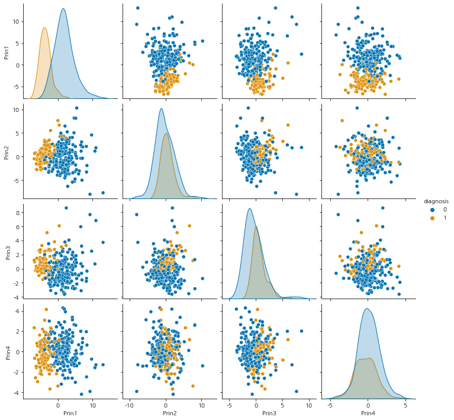

```python
x_var= ["Prin1", "Prin2", "Prin3", "Prin4"]
df_scatter1 = pd.concat([df_pca[x_var], df_raw_y], axis=1)
sns.pairplot(df_scatter1, hue="diagnosis", palette="colorblind")
```

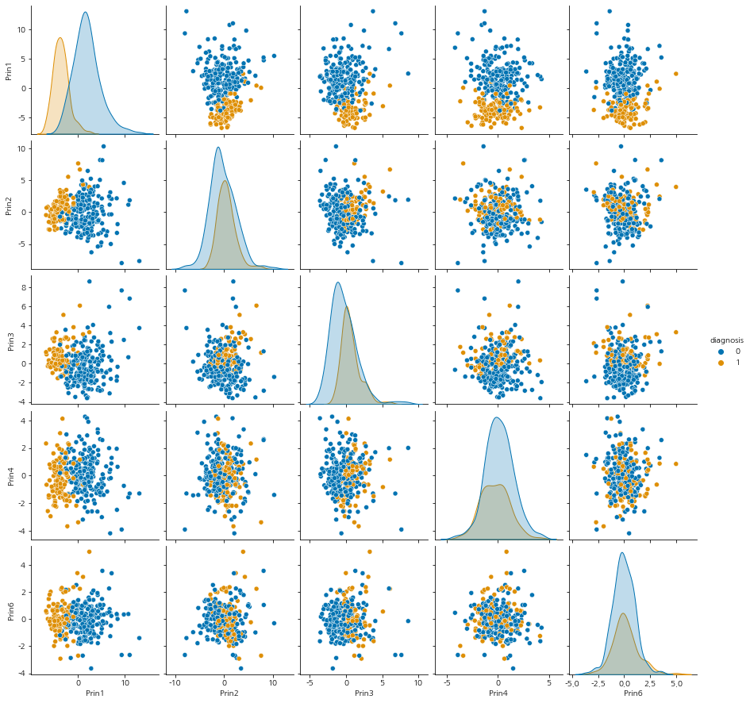

```python
x_var= ["Prin1", "Prin2", "Prin3", "Prin4", "Prin6"]
df_scatter2 = pd.concat([df_pca[x_var], df_raw_y], axis=1)
sns.pairplot(df_scatter2, hue="diagnosis", palette="colorblind")
```

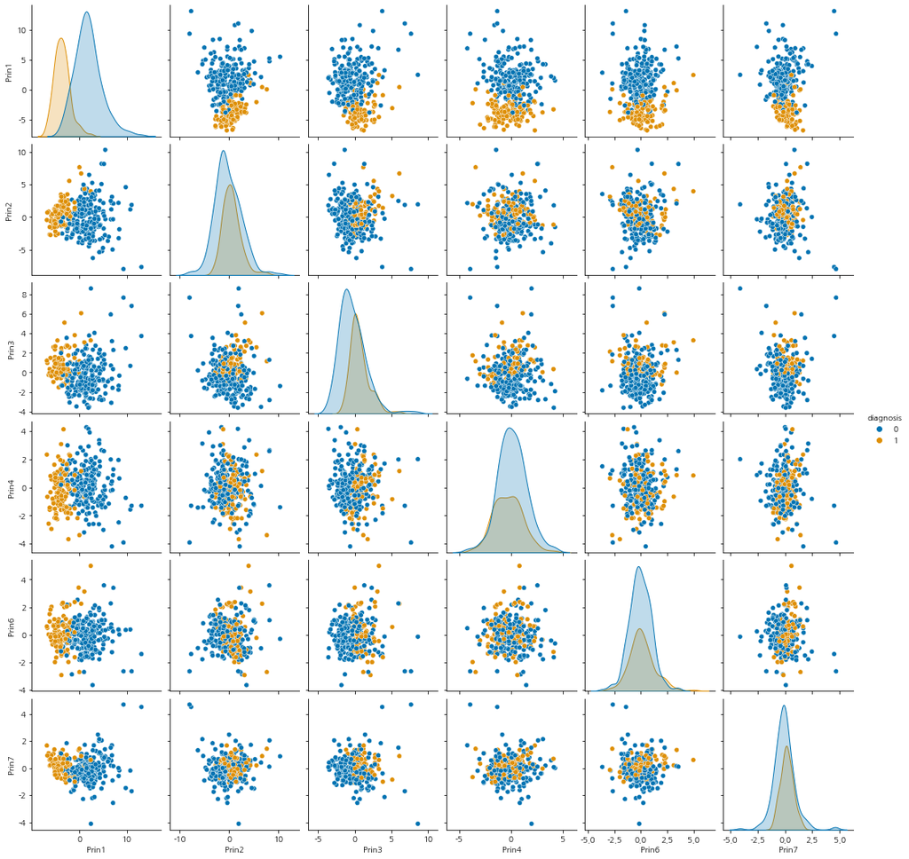

```python
x_var= ["Prin1", "Prin2", "Prin3", "Prin4", "Prin6", "Prin7"]
df_scatter3 = pd.concat([df_pca[x_var], df_raw_y], axis=1)
sns.pairplot(df_scatter3, hue="diagnosis", palette="colorblind")
```

산점도를 보면, 1주성분을 넣었을 때 양성/음성의 구분이 잘 되는 것을 확인할 수 있다. 2-6주성분을 넣었을 때의 경우에는, 1주성분만큼 구분을 잘 하지 못한다는 것을 확인할 수 있었다.  
즉, 1주성분을 넣었을 때 모델의 설명력이 많이 높아진다고 생각할 수 있다.

## Naming

1. 1주성분은 mean_concavity, worst_concave_points 등의 변수와 음의 연관성을 가진다. 둘다 concave(오목한)이라는 의미를 담고 있으므로 'concavity'라는 이름으로 부를 수 있다.
2. 2주성분은 mean_fractal_dimension, worst_fractal_dimension 등의 변수와 음의 연관성을 가진다. 둘다 fractal이라는 단어가 포함되어 있는데, 이는 세포의 프랙탈적 특성을 의미한다. 그러므로 'fractal'이라는 이름으로 부를 수 있다.
3. 3주성분은 smoothness_error, texture_error 등의 변수와 음의 연관성을 가진다. smoothness은 평평함, texture는 표면을 의미한다. 즉, 형태를 나타내는 단어라고 할 수 있으므로 'shape'라는 이름으로 부를 수 있다.
4. 4주성분은 mean_texture, worst_texture와 강한 음의 연관성을 가진다. 둘다 texture(표면)라는 단어를 포함하으로 'texture'라는 이름으로 부를 수 있다.
5. 5주성분은 symmetry_error, worst_symmetry와 강한 양의 연관성을 가진다. symmetry는 대칭이라는 뜻이므로 'symmetry'라고 부를 수 있다.
6. 7주성분은 perimeter_error, area_error와 음의 연관성을 가진다. perimeter는 구역의 주변, area는 구역을 의미한다. 그러므로 'area'라는 이름으로 부를 수 있다.

<정리>  
1주성분: concavity  
2주성분: fractal  
3주성분: shape  
4주성분: texture  
5주성분: symmetry  
7주성분: area